# Introduction to Bayesian Statistics for Demographic Science

# 3 Specifying a binomial model using `Stan` and `CmdStanR`.

There is different software to carry out Bayesian inference. One of the most recent and popular software is [`Stan`](https://mc-stan.org/), which we are using in this lab for estimating the probability that aa newborn in a given hospital is a girl as in the previous section.

## 3.1 Basics of `Stan` and `CmdStanR`

To use `Stan` in `R`, we need the to install and load the `CmdStanR` package. Depending on your computer, you will be asked to install `Rtools`. Install it and be patient, given that it takes a little bit of time.

```r
install.packages("cmdstanr", repos = c('https://stan-dev.r-universe.dev', getOption("repos")))
```

```r
library("cmdstanr")
library("posterior")
library("bayesplot")
color_scheme_set("brightblue")
```

You can write a `Stan` program in a text editor, saving them with the extension `.stan` at the end of the file name (e.g. `model.stan`). You can also write a `Stan` program in RStudio as we are going to do in this lab.

## 3.2 Writing a model in `Stan`

Stan works in six blocks of code, which correspond to `data`, `parameters`, `model`, `transformed data`, `transformed parameters`, and `generated quantities`. You need to define at least the three first blocks.

- The `data` block comprehends the input data. You need to define all the elements that your model requires. For our case, the elements are the sample size and the data denoting whether a girl or boy is born.
- The `parameters` block includes the parameters of our interest. In out case is $\theta$, which is bounded between $0$ and $1$ due to being a probability.
- In the `model` block, you need to specify not only the likelihood for a model but also its priors.

[output not shown]

[output not shown]

- The `transformed data` block, in which you can specify any transformation of the input data.
- The `transformed parameters` block which enables the definition of intermediate parameters when the likelihood requires to be specified in a different ways.
- The `generated quantities` block, from which you can make predictions based on the resulting posterior.

## 3.3 Formatting input data and initial values for `Stan` model

Once the model is specified, you need to format the input data to be used. `Stan` accepts data in a `list` format as follows

```r
data.inp <- list(k = sum(girl[1:20]),
                 N = 20)
```

To obtain easily convergence of the model, you can also define initial values. In our case, it is sensible to include $0.5$ as an initial value of our parameter $\theta$.

```r
inits00 <- list(theta=0.5)
```

## 3.4 Model estimation

```r
fit.bin <- mod0$sample(
  data = data.inp,
  chains = 2,
  parallel_chains = 2,
  iter_warmup = 500,
  iter_sampling = 1000,
  seed = 26,
  init = list(inits00, inits00)  # A list of initial values for each chain
)
```

[output not shown]

## 3.5 Basic diagnostics

Before looking at the posterior distribution, you need to perform basic diagnostics.

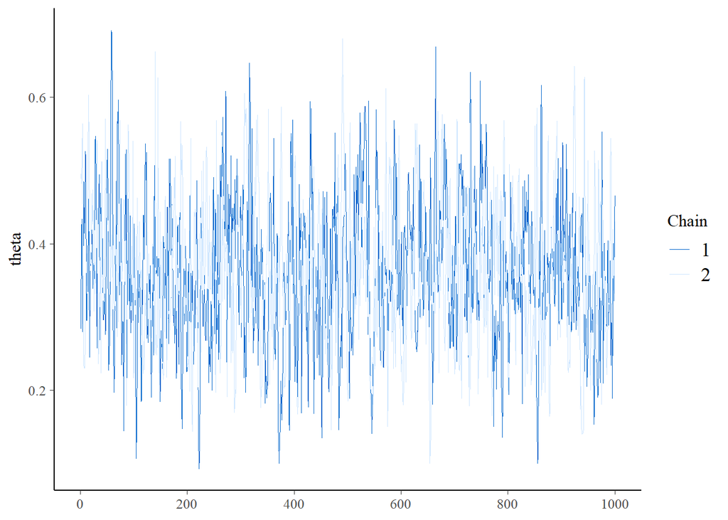

```r
# Extract the posterior draws for the parameter `theta`
posterior_draws <- fit.bin$draws(variables = "theta")

# Trace plot for `theta`
mcmc_trace(posterior_draws, pars = "theta", inc_warmup = FALSE)
```

Now, look at the posterior.

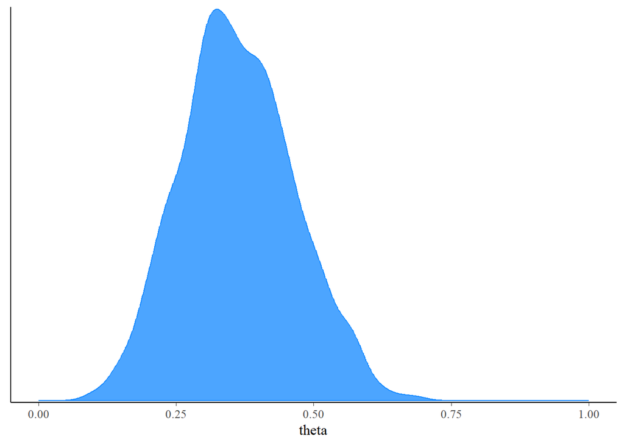

```r
# Density plot for `theta` with limits on the x-axis
mcmc_dens(posterior_draws, pars = "theta") +
  scale_x_continuous(limits = c(0, 1))
```